# Data exploration

Lodewic van Twillert

22 October, 2018

```r
# PYTHON

# There are some issues with reticulate which causes R to crash when using
# python chunks in Rmarkdown with python from a conda environment
#   Might not be the case on Ubuntu / AWS servers but for now we use a workaround
#   with py_run_string()

py_run_string("
import dill
import sklearn as sk
import numpy as np
import pandas as pd
")
```

```r
# Python code

# Read data from s3 amazon instance
py_run_string("
data = pd.read_csv('https://s3.amazonaws.com/drivendata/data/7/public/4910797b-ee55-40a7-8668-10efd5c1b960.csv', encoding = 'iso-8859-1')
labels = pd.read_csv('https://s3.amazonaws.com/drivendata/data/7/public/0bf8bc6e-30d0-4c50-956a-603fc693d966.csv', encoding = 'iso-8859-1')

# A .docx was provided with feature descriptions. This was formatted as a csv file.
features = pd.read_csv('../data/raw/water_pump_features.csv')
")
```

```r
# Hyper parameters

# Read data
# df <- read.csv("../data/raw/water_pump_set.csv")
# labels <- read.csv("../data/raw/water_pump_labels.csv")
# feature_desc <- read.csv("../data/raw/water_pump_features.csv")
```

# Predicting Tanzania water pump maintenance

### The data

The case presented here is about water pumps in Tanzania. The data set originates from the Tanzanian Ministry of Water. Currently, this ministry maintains its pumps based on a maintenance schedule or, of course, when they break down. We feel that the maintenance of the Tanzanian water pumps could improve in both the cost of maintenance and the prevention of break downs by introducing machine learning to predict if a water pump is in need of repair or even the moment of failure of each water pump.

### Objective

Our objective is to develop a reproducible model that can predict which pumps will fail in the future, either the moment or just whether they fail. The resulting model is to be used by the Tanzanian government to effectively maintain their water pumps.

Normally for this type of data you would expect that a single water pump was measured over-time and using this data we could predict the need for repairs for a given pump. In this case however, at every practically every timepoint a different water point was measured! So we have to make some assumptions about the data and the approach to how we create a model.

#### Assumptions

**We should know in advance which water point should be predicted**, there must be something like a maintenance schedule at least 3 days ahead. We make this assumption because we have to able to take into account the measured variables about the water pumps.!

**Measured variable should all be assumed to be known in advance**, otherwise we should choose to leave out some variables that may have only become known at the time of determining the functioning of a water pump. Variables like the `funder` and `district_code` are clearly known ahead of maintenance, but other variables like `water_quality` and `amount_tsh` (total amount water available to waterpoint) may not be known before determining the state of the pump.

# Getting a feeling for the data

Before we start modelling the data we should understand the data. In this dataset we find a total of 40 measured variables to be used as features in our models. In this section we will aim to understand these features and make motivated choices to keep, remove or transform these features from our prediction model.

## A closer look at our features

Our data consists of, - 59400 observations - 40 features - 3 types of labels to predict

Not all of the features are necessarily useful for predicting the moment of failure of water pumps, for instance the measurement `id` won’t be of much use at it is unique.

First we’ll take a look at the raw data to fully understand the structure of our data, especially how exactly the data was measured over time. We have 59400 observations.

### Raw data

```r
ShowDataTable(py$data[1:6,])
```

|  | id | amount_tsh | date_recorded | funder | gps_height | installer | longitude | latitude | wpt_name | num_private | basin | subvillage | region | region_code | district_code | lga | ward | population | public_meeting | recorded_by | scheme_management | scheme_name | permit | construction_year | extraction_type | extraction_type_group | extraction_type_class | management | management_group | … |
| --- | --- | --- | --- | --- | --- | --- | --- | --- | --- | --- | --- | --- | --- | --- | --- | --- | --- | --- | --- | --- | --- | --- | --- | --- | --- | --- | --- | --- | --- | --- |
| 1 | 69572 | 6000 | 2011-03-14 | Roman | 1390 | Roman | 34.93809275 | -9.85632177 | none | 0 | Lake Nyasa | Mnyusi B | Iringa | 11 | 5 | Ludewa | Mundindi | 109 | True | GeoData Consultants Ltd | VWC | Roman | False | 1999 | gravity | gravity | gravity | vwc | user-group | … |
| 2 | 8776 | 0 | 2013-03-06 | Grumeti | 1399 | GRUMETI | 34.6987661 | -2.14746569 | Zahanati | 0 | Lake Victoria | Nyamara | Mara | 20 | 2 | Serengeti | Natta | 280 |  | GeoData Consultants Ltd | Other |  | True | 2010 | gravity | gravity | gravity | wug | user-group | … |
| 3 | 34310 | 25 | 2013-02-25 | Lottery Club | 686 | World vision | 37.46066446 | -3.82132853 | Kwa Mahundi | 0 | Pangani | Majengo | Manyara | 21 | 4 | Simanjiro | Ngorika | 250 | True | GeoData Consultants Ltd | VWC | Nyumba ya mungu pipe scheme | True | 2009 | gravity | gravity | gravity | vwc | user-group | … |
| 4 | 67743 | 0 | 2013-01-28 | Unicef | 263 | UNICEF | 38.48616088 | -11.15529772 | Zahanati Ya Nanyumbu | 0 | Ruvuma / Southern Coast | Mahakamani | Mtwara | 90 | 63 | Nanyumbu | Nanyumbu | 58 | True | GeoData Consultants Ltd | VWC |  | True | 1986 | submersible | submersible | submersible | vwc | user-group | … |
| 5 | 19728 | 0 | 2011-07-13 | Action In A | 0 | Artisan | 31.13084671 | -1.82535885 | Shuleni | 0 | Lake Victoria | Kyanyamisa | Kagera | 18 | 1 | Karagwe | Nyakasimbi | 0 | True | GeoData Consultants Ltd |  |  | True | 0 | gravity | gravity | gravity | other | other | … |
| 6 | 9944 | 20 | 2011-03-13 | Mkinga Distric Coun | 0 | DWE | 39.1727956 | -4.76558728 | Tajiri | 0 | Pangani | Moa/Mwereme | Tanga | 4 | 8 | Mkinga | Moa | 1 | True | GeoData Consultants Ltd | VWC | Zingibali | True | 2009 | submersible | submersible | submersible | vwc | user-group | … |

With the data above we will aim to predict the labels, indicating the need of repair or rather the functional state of water pumps. There are 59400 possible labels,

Each of these labels is associated with a unique measurement `id`.

```r
head(py$labels)
```

```
##      id   status_group
## 1 69572     functional
## 2  8776     functional
## 3 34310     functional
## 4 67743 non functional
## 5 19728     functional
## 6  9944     functional
```

```r
df_dates <- py$data %>% select(id, date_recorded) %>%
  merge(., py$labels) %>%
  mutate(date_recorded = as.Date(date_recorded, "%Y-%m-%d")) %>%
  arrange(date_recorded) %>%
  mutate(days_diff = as.numeric(date_recorded - lag(date_recorded)),
         week_recorded = as.numeric(strftime(date_recorded, format = "%V")),
         month_recorded = as.numeric(strftime(date_recorded, format = "%m")),
         year_recorded = strftime(date_recorded, format="%Y"))
```

```r
# Summary of days since last maintenance
yearly_days_between_obs <- df_dates %>%           # First row will always have NA days_diff so remove it.
  group_by(year_recorded) %>%
  summarise(n = n(),
            median = median(days_diff, na.rm = T),
            mean = round(mean(days_diff, na.rm = T), 2),
            max = max(days_diff, na.rm = T))
```

### Features

The most important part of this project is, of course, the data. The data consists of measured variables that we can use to predict the status of a given water pump.

```r
feature_desc <- py$features %>%
  mutate(example = as.character(py$data[1, -1]), # First row of the data without the 'id' column
         unique = map_int(py$data[,-1],function(x) length(unique(x))),
         type = map_chr(py$data[,-1], function(x) ifelse(is.numeric(x), "numeric", "character")))
```

The labels of the dataset can already help us reduce the dimensions of the dataset. While we present the labels below think about variables that

- were measured and represented in numerical values
  - alteratively categorical values or labels
- represent unique measurements
- can be used to predict water pump need of repair

The **numerical labels** are as follows,

```r
datatable(feature_desc %>%
            filter(type == "numeric") %>%
            arrange(unique),
          extensions="Scroller", style="bootstrap", class="compact", width="100%",
  options=list(deferRender=TRUE, scroller=TRUE))
```

|  | Feature | Description | example | unique | type |
| --- | --- | --- | --- | --- | --- |
| 1 | district_code | Geographic location (coded) | 5 | 20 | numeric |
| 2 | region_code | Geographic location (coded) | 11 | 27 | numeric |
| 3 | construction_year | Year the waterpoint was constructed | 1999 | 55 | numeric |
| 4 | num_private |  | 0 | 65 | numeric |
| 5 | amount_tsh | Total static head (amount water available to waterpoint) | 6000 | 98 | numeric |
| 6 | population | Population around the well | 109 | 1049 | numeric |
| 7 | gps_height | Altitude of the well | 1390 | 2428 | numeric |
| 8 | longitude | GPS coordinate | 34.93809275 | 57516 | numeric |
| 9 | latitude | GPS coordinate | -9.85632177 | 57517 | numeric |

```r
plotly::ggplotly(
  feature_desc %>%
    filter(type == "numeric") %>%
    arrange(unique) %>%
    mutate(Feature = factor(Feature, levels = as.character(Feature))) %>%
    ggplot(aes(x = Feature, y = unique, label = unique, fill = unique)) +
    geom_bar(stat="identity") +
    geom_text(nudge_y = 1000) +
    coord_flip() +
    ggtitle("Unique values of numerical features") +
    theme_fivethirtyeight()
)
```

[interactive chart not shown]

```r
# length(unique(df$wpt_name))
```

```r
add_na_col <- function(x){
  mutate(x, na = 0)
}

has_n_col <- function(x, n = 6){
  return(ncol(x) == n)
}

summarise_char <- function(x) {
  list(n_unique = length(unique(x)),
       n_empty = length(x == "" | is.na(x)))
}
```

#### Days between observations

```r
yearly_days_between_obs
```

```
## # A tibble: 5 x 5
##   year_recorded     n median   mean   max
##   <chr>         <int>  <dbl>  <dbl> <dbl>
## 1 2002              1     NA NaN     -Inf
## 2 2004             30      0  26.0    450
## 3 2011          28674      0   0.09  2224
## 4 2012           6424      0   0.06   250
## 5 2013          24271      0   0.01    30
```

```r
# Daily counts of water pump status groups
plotly::ggplotly(
  df_dates %>% filter(year_recorded > 2004) %>%
    group_by(year_recorded, month_recorded, status_group) %>%
    # summarise(count = n()) %>%
    ggplot(aes(x = month_recorded, fill = status_group)) +
      geom_bar(position = "stack") + facet_grid(year_recorded~.)
)
```

[interactive chart not shown]

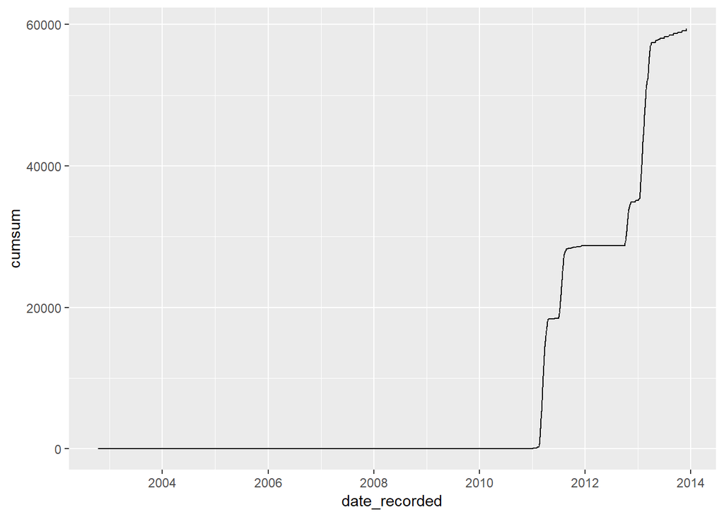

```r
df_dates %>%
  ungroup() %>%
  arrange(date_recorded) %>%
  group_by(date_recorded) %>%
  summarise("total" = n()) %>%
  mutate(cumsum = cumsum(total)) %>%
ggplot(aes(x = date_recorded, y = cumsum)) + geom_line()
```

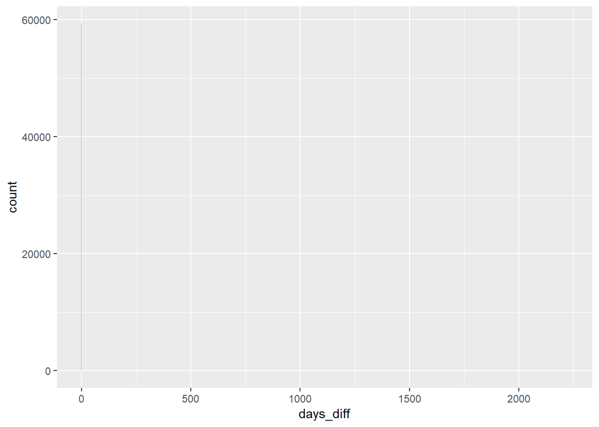

```r
df_dates[-1,] %>%
  filter(year_recorded > 2004) %>%
  ggplot(aes(x = days_diff)) + geom_histogram(position="dodge", alpha = 0.5, bins = 1000)
```

In our case we will treat the data as a timeseries, so it is important for us to know the timeperiod that is covered and the frequency of measurements. Let’s start with the number of observations per year,

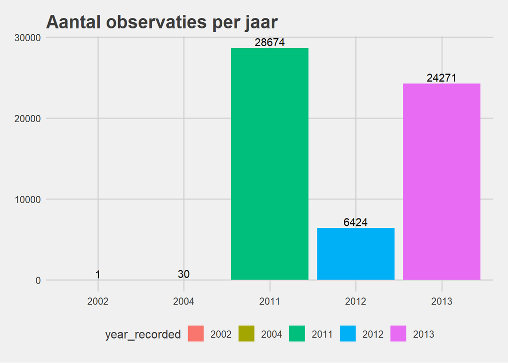

```r
# Barplot of number of observations per year
df_dates %>%
  group_by(year_recorded) %>%
  summarise(observations = n()) %>%
  ggplot(aes(x = year_recorded, y = observations, fill = year_recorded)) +
  geom_bar(stat = "identity") +
  geom_text(aes(label=observations), position=position_dodge(width=0.9), vjust=-0.25) +
  ggtitle("Aantal observaties per jaar") +
  theme_fivethirtyeight()
```

As we can see, the data is measured between 2002 and 2013, but there is only a single observation in 2002 and 30 measurements in 2004. There is a massive gap where no measurements were taken between 2004 and 2011.

Measurements in 2002 and 2004 are scarce and we can motivate the preference to remove these observations from our analysis, at least temporarily. The data from the past needs to generalize well to unseen future observations in order for our predictive model to work well. Because of the importance of the ability to generalize past data to future scenarios we will filter out the data from 2002 and 2004, making the assumption that these measurements will not generalize well to the rest of the dataset. Later in the analysis we will test this assumption in more detail.

### Labels

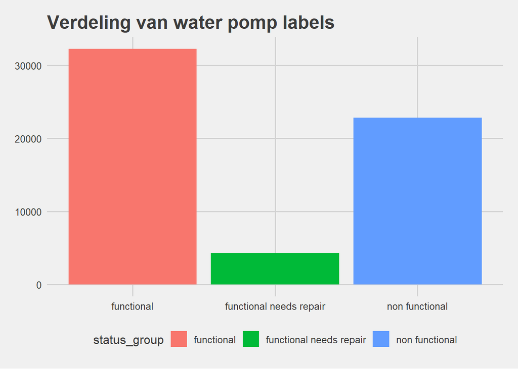

```r
py$labels %>%
  ggplot(aes(x = status_group, fill = status_group)) +
  geom_bar() +
  ggtitle("Verdeling van water pomp labels") +
  theme_fivethirtyeight()
```

```r
label_ratios = table(py$labels$status_group) / nrow(py$labels)
label_ratios
```

```
##
##              functional functional needs repair          non functional
##              0.54308081              0.07267677              0.38424242
```

Now, these ratios are far from constant over time but there does not appear to be a clear independent pattern over time We have to keep in mind that the dataset has some very large gaps, seen from the gaps in the plot below.

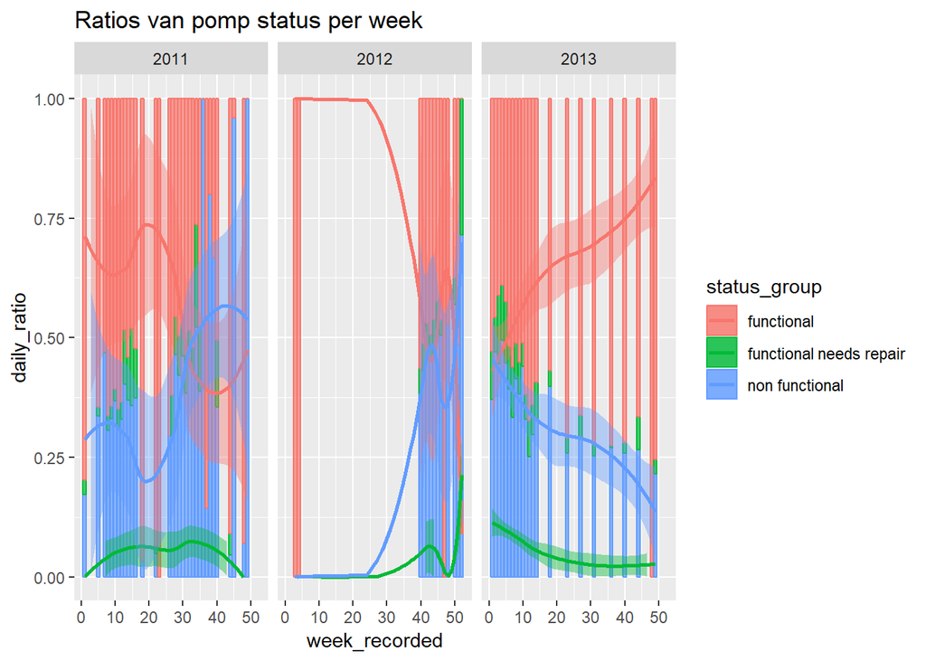

```r
df_dates %>%
  filter(year_recorded > 2004) %>%
  mutate(status_group = factor(status_group)) %>%
  group_by(year_recorded, week_recorded, status_group) %>%
  summarise(n = n()) %>%
  complete(status_group) %>%
  mutate(daily_ratio = ifelse(is.na(n), 0, n) / sum(n, na.rm = T)) %>%
  ggplot(aes(x = week_recorded, y = daily_ratio, fill = status_group, color = status_group)) +
    geom_bar(stat = "identity", alpha=0.7) +
    geom_smooth() +
    ylim(c(0, 1)) +
    facet_grid(.~year_recorded) +
    ggtitle("Ratios van pomp status per week")
```

```r
    theme_fivethirtyeight()
```

[output not shown]

[output cut: 343 more lines]

[output not shown]

### Numerical values

Of the 40 features of the water pump data, we have 10 numerical values. From these numerical values we can at least exclude the `id`.

```r
# Summarise numerical values
py$data %>%
  select(-id) %>%
  select_if(is.numeric)  %>%
  map(~as.tibble(c(
    summary(.x),                        # compute tidy summary of each var
    list(nonzero = sum(.x != 0),        # Add number of nonzero values
         unique = length(unique(.x)))      # Add number of unique values
    ))) %>%
  do.call(rbind, .) -> df_num_summary  # bind list elements into df
```

```r
cat(paste0(c("Numerical measured features",
           rownames(df_num_summary)),
           collapse = "\n\t- ")
    )
```

Numerical measured features - amount_tsh - gps_height - longitude - latitude - num_private - region_code - district_code - population - construction_year

A quick summary of these values can tell us more about the structure of the data. The first thing we’ll notice is that there are no `NA` values in the data, a very pleasant surprise!

```r
datatable(df_num_summary)
```

|  | Min. | 1st Qu. | Median | Mean | 3rd Qu. | Max. | nonzero | unique |
| --- | --- | --- | --- | --- | --- | --- | --- | --- |
| amount_tsh | 0 | 0 | 0 | 317.650384680135 | 20 | 350000 | 17761 | 98 |
| gps_height | -90 | 0 | 369 | 668.297239057239 | 1319.25 | 2770 | 38962 | 2428 |
| longitude | 0 | 33.09034738 | 34.90874343 | 34.0774266920288 | 37.17838657 | 40.34519307 | 57588 | 57516 |
| latitude | -11.64944018 | -8.540621305 | -5.02159665 | -5.70603265962643 | -3.32615564 | -2e-08 | 59400 | 57517 |
| num_private | 0 | 0 | 0 | 0.474141414141414 | 0 | 1776 | 757 | 65 |
| region_code | 1 | 5 | 12 | 15.2970033670034 | 17 | 99 | 59400 | 27 |
| district_code | 0 | 2 | 3 | 5.62974747474748 | 5 | 80 | 59377 | 20 |
| population | 0 | 0 | 25 | 179.909983164983 | 215 | 30500 | 38019 | 1049 |
| construction_year | 0 | 0 | 1986 | 1300.65247474747 | 2004 | 2013 | 38691 | 55 |

# Summarise non-numerical values like categories and strings

The water pump data is surprising in that it is not really a timeseries that you would normally see in similar cases where the objective is to predict system failure using sensor data over time. In the data we’ll find a feature named `wpt_name`, short for waterpoint name, a name that is intuitively unique for every water pump. However… When we look at the non-numerical variables we see that many of the labels have a large number of unique values, as expected, but these also include `wpt_name`!